# Unveiling Structural Linear Dependencies Of Handwritten Digits

## STA437 Final Project Codes and Documentations

### Author: Zixiang Zhang

This JupiterNotebook demonstrated the codes I(Zixiang Zhang) used to conduct the experiment in essay "Unveiling Structural Linear Dependencies Of Handwritten Digits". This is part of my STA437 final project, which is done individually.

**Generative AI Usage Notification**:

In the coding, Google Gemini 3 Pro was used for debugging, providing coding suggestions and help formatting the coding. However, the core algorithm of coding itself, implementations, documentations, structure and research process, writing of comments and so on are done individually by me(Zixiang Zhang). AI is used for very specific questions or repetitive work that consumes time, instead of a task.

The essay and its intepretations are also written individually by me(Zixiang Zhang).

**Referenced Files**

Though the project is written in Python, some R Codes in the course files have provided some ideas of mine. These files including:

- practice5-pca.html
- practice6-pca-variants.html
- practice7-cca.html

# Requirements to Run the Code

**Python 3.13.0 is required to run the code flawlessly.** Other versions may encounter zero division problems in the linear regression part. PyCharm is the IDE for coding.

Before you start, use this commend in terminal of your IDE to install some of the dependencies used:

```
pip install pandas seaborn numpy matplotlib scikit-learn
```

After installing dependencies, follow the steps below to run this project.

1. run the import chunk
2. run the function chunk
3. run the code in the chunk afterwards, each chunk has been labeled to the figures that belongs to them

### 1. Environment Configuration and Loading mnist.csv

```python
import pandas as pd
import seaborn as sns
import numpy as np
import matplotlib.pyplot as plt
import os
from sklearn.cross_decomposition import CCA
from sklearn.decomposition import PCA
from sklearn.linear_model import LinearRegression
from sklearn.preprocessing import StandardScaler

DATA_PATH = "mnist.csv" # the mnist dataset I used in this project is
                                        # from STA437 course folder.
sns.set_theme(style="whitegrid", context="paper", font_scale=1.2)
if not os.path.exists("plots"):
    os.makedirs("plots")
```

### 2. Customized Functions Chunk

Running this chunk will get all the functions that used in the experiment ready to run. The chunk will not provide you the outputs. For the output, see the chunks after this.

Note that as a some samples are selected randomly. However, the behaviour and pattern is consistent as described and ready for you to verify. As stated: top/bottom split is less focused on the spatial position of left/right splits.

```python
def load_data_global(path, sample_size=5000):
    """
    Load data from mnist.csv
    """
    if not os.path.exists(path):
        print(f"Error: {path} not found.")
        return None, None

    df = pd.read_csv(path)

    y = df.iloc[:, 0].values
    X = df.iloc[:, 1:].values

    return X, y


def get_image_splits(X_input, mode='LR', img_size=28):
    """
    mode: 'LR' - Left / Right Split
    mode: 'TB' - Top / Bottom Split
    mode: '4way' - Top Bottom / Left / Right Split all together
    """
    n_samples = X_input.shape[0]
    cut = img_size // 2
    X_img = X_input.reshape(n_samples, img_size, img_size)

    splits = {}

    if mode in ['LR', '4Way']:
        splits['Left'] = X_img[:, :, :cut].reshape(n_samples, -1)
        splits['Right'] = X_img[:, :, cut:].reshape(n_samples, -1)

    if mode in ['TB', '4Way']:
        splits['Top'] = X_img[:, :cut, :].reshape(n_samples, -1)
        splits['Bottom'] = X_img[:, cut:, :].reshape(n_samples, -1)

    return splits


def compute_pca_cca_pipeline(X1, X2, n_components):
    """
    PCA -> CCA Algorithm
    n_components: number of components
    X1: one side of image of a given dividing algorithm
    X2: other side of image of the same dividing algorithm as X1
    """
    try:
        # 1. PCA
        pca1 = PCA(n_components=n_components, random_state=42)
        pca2 = PCA(n_components=n_components, random_state=42)
        X1_pca = pca1.fit_transform(X1)
        X2_pca = pca2.fit_transform(X2)

        # 2. CCA
        cca = CCA(n_components=1)
        cca.fit(X1_pca, X2_pca)
        U, V = cca.transform(X1_pca, X2_pca)
        corr = np.corrcoef(U[:, 0], V[:, 0])[0, 1]

        return {
            'corr': corr,
            'pca1': pca1, 'pca2': pca2,
            'cca': cca,
            'w1': cca.x_weights_[:, 0],  # X1 Weight
            'w2': cca.y_weights_[:, 0]  # X2 Weight
        }
    except Exception as e:
        print(f"Pipeline Error: {e}")
        return None


def visualize_cca_geometry(X, y, n_components, mode='LR'):
    """
    Run CCA visualizations based on the mode selected.

    mode: 'LR' - Left / Right Split
    mode: 'TB' - Top / Bottom Split
    mode: '4way' - Top Bottom / Left / Right Split all together

    """
    fig, axes = plt.subplots(2, 5, figsize=(15, 7))
    axes = axes.flatten()
    cmap = 'seismic'

    key1, key2 = ('Left', 'Right') if mode == 'LR' else ('Top', 'Bottom')

    img_size = 28
    cut = 14

    for digit in range(10):
        # 1. Data normalization
        X_digit = X[y == digit] / 255.0
        splits = get_image_splits(X_digit, mode=mode)

        # 2. performing compute_pca_cca_pipeline.
        res = compute_pca_cca_pipeline(splits[key1], splits[key2], n_components)

        cca_img = np.zeros((img_size, img_size))
        corr = 0

        if res:
            corr = res['corr']
            # Back-projection
            # pattern = Weight * PCA_Components
            pat1 = np.dot(res['w1'], res['pca1'].components_)
            pat2 = np.dot(res['w2'], res['pca2'].components_)

            # merge matrix into one
            if mode == 'LR':
                cca_img[:, :cut] = pat1.reshape(28, 14)
                cca_img[:, cut:] = pat2.reshape(28, 14)
            else:  # mode == 'TB'
                cca_img[:cut, :] = pat1.reshape(14, 28)
                cca_img[cut:, :] = pat2.reshape(14, 28)

        # 3. Draw Visualizations
        ax = axes[digit]
        v_max = np.max(np.abs(cca_img)) if np.max(np.abs(cca_img)) > 0 else 1
        ax.imshow(cca_img, cmap=cmap, vmin=-v_max, vmax=v_max)
        ax.axis('off')
        ax.set_title(f" ρ = {corr:.3f}", fontsize=12, fontweight='bold')

    plt.suptitle(f"{mode} mode - CCA Correlation Patterns with {n_components}PCs",
                 fontsize=16)
    plt.tight_layout()
    plt.show()


def verify_variance_coverage(X, y, n_components):
    """
    Verifying the variance explained by n_components PCAs.
    Normally, this number is set to 5. In my essay, it's set to 20 and 5,
    to demonstrate that the image data is highly redundant and showing that
    around 50% of the variance could be explained by first 5 PCs, and around 80%
    of the variance could be explained by first 20 PCs.
    """
    print(f"\n--------- Variance Explained By {n_components} PCs ---------")
    data = []

    for digit in range(10):
        X_digit = X[y == digit] / 255.0
        splits = get_image_splits(X_digit, mode='4Way')  # Splitting image into 4 parts

        # the following loop calculates the given number of PCs' variance explained.
        # In essay it's 5.
        # corrospond to their own parts.
        # The loop will find each of them and merge into a summary table.

        row = {"Digit": digit}
        for key in ['Left', 'Right', 'Top', 'Bottom']:
            pca = PCA(n_components=n_components, random_state=42)
            pca.fit(splits[key])
            row[f"{key}_Var"] = np.sum(pca.explained_variance_ratio_)

        data.append(row)

    df = pd.DataFrame(data)
    print(df.set_index("Digit").map(lambda x: f"{x:.1%}").to_markdown())

    print(f"Average Variance of Left Split: {df['Left_Var'].mean():.1%}")
    print(f"Average Variance of Right Split: {df['Right_Var'].mean():.1%}")
    print(f"Average Variance of Top Split: {df['Top_Var'].mean():.1%}")
    print(f"Average Variance of Bottom Split: {df['Bottom_Var'].mean():.1%}")

def inspect_cca_weights_unified(X, y, target_digit, n_components, mode='TB'):
    """
    this function will implement the weight of CCA of a given segment
    of picture by visualizing them in barplot.
    normally, only 5 PCs will be displayed unless otherwise defined.
    """

    print(f"\n CCA Weight Barplot - Digit {target_digit}, Mode {mode}")

    # 1. partitioning
    X_digit = X[y == target_digit] / 255.0
    splits = get_image_splits(X_digit, mode=mode)
    key1, key2 = ('Left', 'Right') if mode == 'LR' else ('Top', 'Bottom')

    # 2. Using compute_pca_cca_pipeline to perform calculation of weight,
    # two parts will be assigned to w1 and w2 respectively.
```

```python
    res = compute_pca_cca_pipeline(splits[key1], splits[key2], n_components)
    if not res: return

    w1, w2 = res['w1'], res['w2']

    # 3. print a short summery of the dominant PC
    dom_idx1 = np.argmax(np.abs(w1))
    print(f"Dominant PC in {key1}: PC{dom_idx1 + 1} (Weight: {w1[dom_idx1]:.4f})")

    # 4. Draw the barplot
    fig, axes = plt.subplots(1, 2, figsize=(12, 5))
    x_indices = np.arange(1, n_components + 1)

    for i, (weights, title, color_logic) in enumerate([
        (w1, f"{key1} Side Weights", True),
        (w2, f"{key2} Side Weights", True)
    ]):
        colors = ['red' if x >= 0 else 'blue' for x in weights]
        axes[i].bar(x_indices, weights, color=colors, alpha=0.7)
        axes[i].set_title(title, fontsize=14)
        axes[i].set_xticks(x_indices)
        axes[i].set_xticklabels([f"PC{k}" for k in x_indices])
        axes[i].grid(axis='y', linestyle='--')

    plt.suptitle(f"CCA Weight Distribution ({mode} Split)", fontsize=16)
    plt.tight_layout()
    plt.show()


def inspect_cca_weights_numeric_output(X, y, target_digit, n_components):

    """
    this function will implement the weight of CCA of top/bottom of a digit,
    output will be in table.
    the result of figure visual representation aligns with the numeric value.
    This is not used in the demonstration of essay.
    normally, only 5 PCs will be displayed unless otherwise defined.
    """

    print(f"\n Top/Bottom CCA Weight Distribution for Digit {target_digit} ")

    # 1. digit selection and normalization
    X_digit = X[y == target_digit]
    X_norm = X_digit / 255.0
    # 2. splitting into top and bottom
    splits = get_image_splits(X_norm, mode='TB')

    X_top = splits['Top']
    X_bottom = splits['Bottom']

    # 3. using compute_pca_cca_pipeline to computer the weight
    # X1 -> Top, X2 -> Bottom
    results = compute_pca_cca_pipeline(X_top, X_bottom, n_components)

    if results is None:
        return

    # 4. assigning weight
    w_top = results['w1']
    w_bottom = results['w2']

    # 5. print weight distribution
    print("\n--- CCA Weight Distribution ---")

    df_weights = pd.DataFrame({
        "PC_Index": [f"PC{i + 1}" for i in range(n_components)],
        "Top_Weight": w_top,
        "Bottom_Weight": w_bottom
    })

    # Print original data
    print(df_weights.to_markdown(index=False, floatfmt=".4f"))

    # Identify dominant component
    dominant_idx = np.argmax(np.abs(w_top))
    print(
        f"\n Dominant component: PC{dominant_idx + 1} "
        f"(Weight: {w_top[dominant_idx]:.4f})"
    )


def visualize_pc_matrix_unified(X, y, target_digit, n_components):

    """
    this function will use Top/Bottom/Left/Right split of a given digit.
    After calculated their first n_components, normally 5,
    it will visualize their PC transformed data into heatmap.
    """

    print(f"\n Eigen-Image Matrix Visualization of Digit '{target_digit}' ")

    X_digit = X[y == target_digit] / 255.0
    splits = get_image_splits(X_digit, mode='4Way')

    # Reshaping and Arrange
    config = [
        ('Top', splits['Top'], (14, 28)),
        ('Bottom', splits['Bottom'], (14, 28)),
        ('Left', splits['Left'], (28, 14)),
        ('Right', splits['Right'], (28, 14))
    ]

    fig, axes = plt.subplots(4, n_components, figsize=(3 * n_components, 10))
    cmap = 'seismic'

    # PCA calculation only.
    for row_idx, (name, data, shape) in enumerate(config):
        pca = PCA(n_components=n_components, random_state=42).fit(data)

        for col_idx in range(n_components):
            ax = axes[row_idx, col_idx]
            pc_img = pca.components_[col_idx].reshape(shape)
            v_max = np.max(np.abs(pc_img))

            ax.imshow(pc_img, cmap=cmap, vmin=-v_max, vmax=v_max)
            ax.set_xticks([])
            ax.set_yticks([])

            if row_idx == 0: ax.set_title(f"PC {col_idx + 1}", fontweight='bold')
            if col_idx == 0: ax.set_ylabel(name, fontsize=14, fontweight='bold',
                                           rotation=90)

    plt.suptitle(f"Digit {target_digit}", fontsize=16, y=0.96)
    plt.tight_layout()
    plt.show()


def plot_4way_scree(X, n_components):
    """
    plotting Top/Bottom/Left/Right PCA Scree Plot to be used in the analysis of variance explained.
    """
    print(f"\n Scree Plots of {n_components} PCs")

    splits = get_image_splits(X / 255.0, mode='4Way')

    fig, axes = plt.subplots(2, 2, figsize=(14, 10))
    axes = axes.flatten()
    pc_nums = np.arange(1, n_components + 1)

    # sequence and color
    config = [
        ('Top Half', splits['Top'], '#4c72b0'),
        ('Bottom Half', splits['Bottom'], '#dd8452'),
        ('Left Half', splits['Left'], '#55a868'),
        ('Right Half', splits['Right'], '#c44e52')
    ]

    for i, (name, X_part, color) in enumerate(config):
        # PCA
        pca = PCA(n_components=n_components, random_state=42)
        pca.fit(X_part)
        var_ratio = pca.explained_variance_ratio_

        # plotting
        ax = axes[i]
        ax.plot(pc_nums, var_ratio, marker='o', linestyle='-', color=color,
                linewidth=2, markersize=6)

        # label numeric value of first 3 points.
        for j, val in enumerate(var_ratio[:3]):
            ax.text(pc_nums[j], val + 0.005, f'{val:.1%}', ha='center', va='bottom',
                    fontsize=9, fontweight='bold')

        ax.set_title(f'{name} - Explained Variance', fontsize=14, fontweight='bold')
        ax.set_xlabel('Principal Component')
        ax.set_ylabel('Variance Ratio')
        ax.set_xticks(pc_nums[::2])
        ax.grid(True, linestyle='--', alpha=0.6)

    plt.suptitle(f'PCA Scree Plots: Variance Percentage by {n_components} PCs', fontsize=16, y=1.02)
    plt.tight_layout()
    plt.show()


def display_top_bottom_split(X, y, target_digit):
    """
    This function displays target_digit's top and bottom split image of the raw, normalized data.
    """
    IMG_SIZE = 28
    CUT_ROW = 14  # cutting from middle of horiziontal position
```

```python
    # drawing a random sample of target digit
    sample_digit = X[y == target_digit][0].reshape(IMG_SIZE, IMG_SIZE) / 255.0

    # cutting from 14th row
    sample_top = sample_digit[:CUT_ROW, :]
    sample_bottom = sample_digit[CUT_ROW:, :]

    # plotting data into graphs separately.
    fig_check, ax_check = plt.subplots(1, 3, figsize=(10, 3))
    ax_check[0].imshow(sample_digit, cmap='gray')
    ax_check[0].set_title("Original")

    ax_check[1].imshow(sample_top, cmap='gray')
    ax_check[1].set_title("Top")

    ax_check[2].imshow(sample_bottom, cmap='gray')
    ax_check[2].set_title("Bottom")

    plt.suptitle(" ", fontsize=14, color='red')
    plt.show()


def run_hd_reconstruction_demo(X, y, n_components=5, target_digit=None):
    """
    This function trains a linear regression model as well as the PCA algorithm.
    The image data is first partitoned, and top or left side will be splited into training
    and testing dataset in 9:1, which here is 450 and 50.

    The PCs are then computed by using the training data,
    then desired number of PCs(normally 5)will be used to reduce the dimension
    of testing dataset.

    Then a linear regression model is fitted based on least squares.

    Testing dataset is used to verify our conclusion in the essay.
    An R^2 score will also be outputed as reference

    Linear regression's output will be restored into format of half of image.

    They will then be merged togetherinto a full image
    to compare with the selected original testing data.

    """
    print(f"\nReconstruction of digit {target_digit}")

    # If no input is given, then target digit will be chosen randomly.
    # However, in the figure generating part I have given specific inputs.

    if target_digit is None:
        target_digit = np.random.choice(np.unique(y))

    # 1. data Preparation
    X_full_class = X[y == target_digit]
    n_total = X_full_class.shape[0]

    # 2. randomized data sequence and draw training and testing data with ratio of 9:1
    indices = np.random.permutation(n_total)[:500]
    X_selected = X_full_class[indices]

    # 450 data used for training, remaining 50 used for testing
    X_train_raw = X_selected[:450]
    X_test_raw = X_selected[450:]

    # print(f"Train: {X_train_raw.shape[0]}, Test: {X_test_raw.shape[0]}")

    # 3. spatial splitting process of both training and testing dataset
    splits_train = get_image_splits(X_train_raw / 255.0, mode='4Way')
    splits_test = get_image_splits(X_test_raw / 255.0, mode='4Way')

    # Extracting data from each part and store them to variables

    # Training
    X_train_L, X_train_R = splits_train['Left'], splits_train['Right']  # horizontal
    X_train_T, X_train_B = splits_train['Top'], splits_train['Bottom']  # vertical

    # Testing
    X_test_L, X_test_R = splits_test['Left'], splits_test['Right']  # horizontal
    X_test_T, X_test_B = splits_test['Top'], splits_test['Bottom']  # vertical

    # 4. linear regression model training process of two different splitting algorithms

    # 4.1 HORIZONTAL ALGORITHM
    # data standardization
    scaler_l = StandardScaler().fit(X_train_L)
    scaler_r = StandardScaler().fit(X_train_R)

    X_train_L_std = scaler_l.transform(X_train_L)
    X_train_R_std = scaler_r.transform(X_train_R)

    # PCA based on horizontal training dataset.
    pca_l = PCA(n_components=n_components, random_state=42).fit(X_train_L_std)
    pca_r = PCA(n_components=n_components, random_state=42).fit(X_train_R_std)

    Z_train_L = pca_l.transform(X_train_L_std)
    Z_train_R = pca_r.transform(X_train_R_std)

    # linear regression model fitting - left/right
    map_lr = LinearRegression().fit(Z_train_L, Z_train_R)

    # 4.2 VERTICAL ALGORITHM

    # standardization
    scaler_t = StandardScaler().fit(X_train_T)
    scaler_b = StandardScaler().fit(X_train_B)

    X_train_T_std = scaler_t.transform(X_train_T)
    X_train_B_std = scaler_b.transform(X_train_B)

    # PCA based on vertical training dataset.
    pca_t = PCA(n_components=n_components, random_state=42).fit(X_train_T_std)
    pca_b = PCA(n_components=n_components, random_state=42).fit(X_train_B_std)

    Z_train_T = pca_t.transform(X_train_T_std)
    Z_train_B = pca_b.transform(X_train_B_std)

    # linear regression model fitting - top/bottom
    map_tb = LinearRegression().fit(Z_train_T, Z_train_B)

    # --------------------------------
    # 5. TESTING STAGE

    # horizontal evaluation
    X_test_L_std = scaler_l.transform(X_test_L)
    X_test_R_std = scaler_r.transform(X_test_R)  # Ground Truth for score

    Z_test_L = pca_l.transform(X_test_L_std)
    Z_test_R_true = pca_r.transform(X_test_R_std)

    score_lr = map_lr.score(Z_test_L, Z_test_R_true)

    # vertical evaluation
    X_test_T_std = scaler_t.transform(X_test_T)
    X_test_B_std = scaler_b.transform(X_test_B)  # Ground Truth for score

    Z_test_T = pca_t.transform(X_test_T_std)
    Z_test_B_true = pca_b.transform(X_test_B_std)

    score_tb = map_tb.score(Z_test_T, Z_test_B_true)

    # As stated in the methology part, this linear regression's
    # purpose is showing difference instead of precisely
    # restoring the image, the R^2 score is usually low.
    # I use visual difference to claim my hypothesis instead of this
    # R^2 output as it also can not show the "preference denepdencies"
    # of up/down and left/right division, but it is also used for me
    # to further verify my assumptions.

    print(f"Test Set R^2 Score (Left/Right): {score_lr:.4f}")
    print(f"Test Set R^2 Score (Top/Bottom): {score_tb:.4f}")

    # 5. reconstructing imgae based on a given digit's random sample fron its 50 testing samples.
    # Output index of the sample being used to predict and compare
    test_idx = np.random.randint(0, 50)
    print(f"Visualizing Test Sample Index: {test_idx}")

    # Extracting original image of that number for comparison.
    sample_img_orig = (X_test_raw[test_idx] / 255.0).reshape(28, 28)

    # Horizontal Reconstruction: using left latent vector (Z_test_L) of testing dataset.
    z_l_input = Z_test_L[test_idx].reshape(1, -1)
    z_r_pred = map_lr.predict(z_l_input)
```

```python
    # Inverse PCA -> Inverse Scaler
    x_r_rec_std = pca_r.inverse_transform(z_r_pred)
    x_r_rec = scaler_r.inverse_transform(x_r_rec_std)

    # Vertical Reconstruction: using top latent vector (Z_test_T) of testing dataset.
    z_t_input = Z_test_T[test_idx].reshape(1, -1)
    z_b_pred = map_tb.predict(z_t_input)

    x_b_rec_std = pca_b.inverse_transform(z_b_pred)
    x_b_rec = scaler_b.inverse_transform(x_b_rec_std)

    # 6. Merging Parts

    # original testing left half merge with reconstructed right half
    img_rec_lr = np.hstack((sample_img_orig[:, :14], x_r_rec.reshape(28, 14)))

    # original testing top half merge with reconstructed bottom half
    img_rec_tb = np.vstack((sample_img_orig[:14, :], x_b_rec.reshape(14, 28)))

    # 7. Figure Generation and Labeling

    fig, axes = plt.subplots(1, 3, figsize=(12, 5))

    axes[0].imshow(sample_img_orig, cmap='gray')
    axes[0].set_title(f"original")
    axes[0].axis('off')

    axes[1].imshow(img_rec_lr, cmap='gray')
    axes[1].set_title(f"horizontal")
    axes[1].axis('off')

    axes[2].imshow(img_rec_tb, cmap='gray')
    axes[2].set_title(f"vertical")
    axes[2].axis('off')

    plt.tight_layout()
    plt.show()


def display_10samples_number(target_digit):

    # Select 10 Random Sample of the Given Number and display their image.

    df = pd.read_csv('mnist.csv')
    digit_2_data = df[df.iloc[:, 0] == target_digit]

    # draw 10 random samples
    samples = digit_2_data.sample(10, random_state=42)

    # convert to grayscale pictures
    fig, axes = plt.subplots(1, 10, figsize=(15, 2))

    for i, (index, row) in enumerate(samples.iterrows()):
        # removing label and convert data format
        pixel_values = row.iloc[1:].values

        # reshape flattened 1x784 data into 28x28 matrix
        image_matrix = pixel_values.reshape(28, 28)

        # plotting image
        axes[i].imshow(image_matrix, cmap='gray')
        axes[i].axis('off')
        axes[i].set_title(f"Sample {i + 1}")

    plt.suptitle(f"10 Random Samples of {target_digit}", fontsize=16)
    plt.tight_layout()
    plt.show()

def display_each_digit_sample(df=None):

    # Display 1 random sample for each digit from 0 to 9
    # For a fixed digit, the sample will be drawn from its 500 samples.

    if df is None:
        df = pd.read_csv('mnist.csv')

    fig, axes = plt.subplots(1, 10, figsize=(15, 2))

    # Repeat from 0 to 9, extract a random sample for the number of that loop and display it.
    for digit in range(10):
        # 1. filtering the target digit
        digit_data = df[df.iloc[:, 0] == digit]

        # 2. draw one sample. Random state is not set here.
        sample = digit_data.sample(1)

        # 3. Data Processing
        pixel_values = sample.iloc[0, 1:].values

        # 4. reshape flattened 1x784 data into 28x28 matrix
        image_matrix = pixel_values.reshape(28, 28)

        # 5. Plotting
        axes[digit].imshow(image_matrix, cmap='gray')
        axes[digit].axis('off')
        axes[digit].set_title(f"{digit}")

    plt.suptitle("Random Sample for Each Digit (0-9)", fontsize=16)
    plt.tight_layout()
    plt.show()

def plot_correlation_summary_bars(X, y, n_components):
    """
    calculate and fit barplot of CCA correlation of all digits in horizontal and vertical splits
    """
    print(f"\n Correlation Summary Barplots (Number of PCs : k={n_components})")

    results = []

    # Normalization
    for digit in range(10):
        X_digit = X[y == digit] / 255.0
        if X_digit.shape[0] < n_components + 1:
            continue

        # splitting in 4 way mode
        splits = get_image_splits(X_digit, mode='4Way')

        # horizontal correlation computation
        res_lr = compute_pca_cca_pipeline(splits['Left'], splits['Right'], n_components)
        corr_lr = res_lr['corr'] if res_lr else 0

        # vertical correlation computation
        res_ud = compute_pca_cca_pipeline(splits['Top'], splits['Bottom'], n_components)
        corr_ud = res_ud['corr'] if res_ud else 0

        results.append({
            'Digit': digit,
            'LR_Correlation': corr_lr,
            'UD_Correlation': corr_ud
        })

    df_results = pd.DataFrame(results)

    # Graph Plotting
    # configurations: blue for horizontal, red for vertical

    plot_configs = [
        ('LR_Correlation', 'Left-Right Correlation', '#87CEEB'),
        ('UD_Correlation', 'Up-Down Correlation', '#F08080')
    ]

    for col, title, color_code in plot_configs:
        plt.figure(figsize=(8, 4))

        # barplot generation
        sns.barplot(x='Digit', y=col, data=df_results, color=color_code,
                    alpha=0.9, edgecolor=".2")

        plt.title(f'{title} (PCA k={n_components})', fontweight='bold')
        plt.ylabel('Canonical Correlation')
        plt.ylim(0, 1.05)
        plt.grid(axis='y', linestyle='--', alpha=0.5)

        # label correlation's value on the bar.
        for index, row in df_results.iterrows():
            plt.text(row.name, row[col] + 0.02, f'{row[col]:.2f}',
                     color='black', ha="center", fontsize=10)

        plt.tight_layout()
        plt.show()


def visualize_digit_pc1_only(X, y, target_digit, n_components):
    # this function only visualize the target_digit's PC1 of four splits.

    X_digit = X[y == target_digit]
    X_norm = X_digit / 255.0
    n_samples = X_norm.shape[0]

    IMG_SIZE = 28
    CUT = 14

    X_img = X_norm.reshape(n_samples, IMG_SIZE, IMG_SIZE)

    #  SPLITTING
    # top
    X_top = X_img[:, :CUT, :].reshape(n_samples, -1)
    # bottom
    X_bottom = X_img[:, CUT:, :].reshape(n_samples, -1)
    # left
    X_left = X_img[:, :, :CUT].reshape(n_samples, -1)
    # right
    X_right = X_img[:, :, CUT:].reshape(n_samples, -1)

    # train PCA and only
    pca_t = PCA(n_components, random_state=42).fit(X_top)
    pca_b = PCA(n_components, random_state=42).fit(X_bottom)
    pca_l = PCA(n_components, random_state=42).fit(X_left)
    pca_r = PCA(n_components, random_state=42).fit(X_right)
```

```python
    # 4. visualization
    fig, axes = plt.subplots(1, 4, figsize=(16, 5))

    plots_config = [
        ("Top Split PC1", pca_t.components_[0], (14, 28)),
        ("Bottom Split PC1", pca_b.components_[0], (14, 28)),
        ("Left Split PC1", pca_l.components_[0], (28, 14)),
        ("Right Split PC1", pca_r.components_[0], (28, 14))
    ]

    cmap = 'seismic'

    for ax, (title, component, shape) in zip(axes, plots_config):

        # Reshape
        pc_img = component.reshape(shape)

        v_max = np.max(np.abs(pc_img))

        im = ax.imshow(pc_img, cmap=cmap, vmin=-v_max, vmax=v_max)
        ax.set_title(title, fontsize=12, fontweight='bold')
        ax.set_xticks([])
        ax.set_yticks([])

        # adding frame
        for spine in ax.spines.values():
            spine.set_edgecolor('gray')
            spine.set_linewidth(1)

    # colorbar setting
    cbar_ax = fig.add_axes([0.92, 0.2, 0.015, 0.6])
    fig.colorbar(im, cax=cbar_ax, label='Pixel Weight (Red+, Blue-)')
    plt.subplots_adjust(wspace=0.3)
    plt.show()
```

# Figures that Appeared in the Essay.

### Figure 1

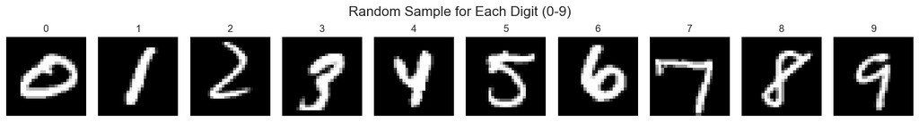

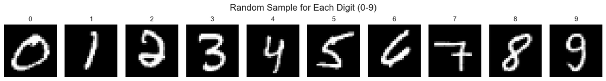

```python
X, y = load_data_global(DATA_PATH, sample_size=5000)
display_each_digit_sample()
display_each_digit_sample()
```

### Figure 2

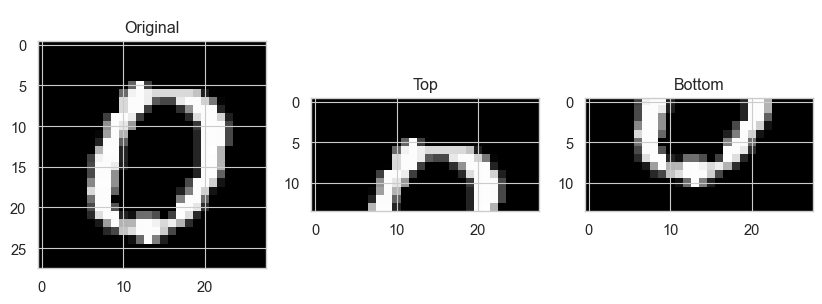

```python
display_top_bottom_split(X, y, target_digit=0)
```

### Figure 3

```
--------- Variance Explained By 20 PCs ---------
|   Digit | Left_Var   | Right_Var   | Top_Var   | Bottom_Var   |
|--------:|:-----------|:------------|:----------|:-------------|
|       0 | 85.7%      | 83.6%       | 83.3%     | 85.6%        |
|       1 | 91.5%      | 90.0%       | 91.1%     | 90.2%        |
|       2 | 79.7%      | 79.2%       | 82.6%     | 77.3%        |
|       3 | 77.2%      | 81.1%       | 80.1%     | 79.8%        |
|       4 | 83.2%      | 80.4%       | 82.6%     | 81.2%        |
|       5 | 78.4%      | 82.1%       | 81.9%     | 80.0%        |
|       6 | 87.2%      | 80.9%       | 86.2%     | 81.8%        |
|       7 | 82.5%      | 83.6%       | 82.2%     | 84.7%        |
|       8 | 80.4%      | 76.2%       | 78.4%     | 78.9%        |
|       9 | 86.3%      | 81.9%       | 84.1%     | 84.7%        |
Average Variance of Left Split: 83.2%
Average Variance of Right Split: 81.9%
Average Variance of Top Split: 83.2%
Average Variance of Bottom Split: 82.4%

 Scree Plots of 20 PCs
```

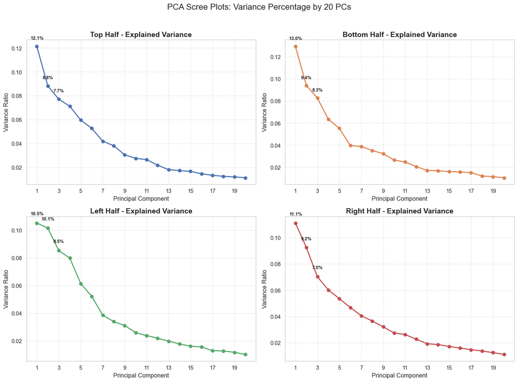

```
--------- Variance Explained By 5 PCs ---------
|   Digit | Left_Var   | Right_Var   | Top_Var   | Bottom_Var   |
|--------:|:-----------|:------------|:----------|:-------------|
|       0 | 60.7%      | 55.8%       | 56.5%     | 59.7%        |
|       1 | 73.7%      | 71.7%       | 73.2%     | 71.8%        |
|       2 | 46.6%      | 46.7%       | 52.0%     | 43.8%        |
|       3 | 45.1%      | 48.5%       | 48.1%     | 48.7%        |
|       4 | 52.0%      | 51.7%       | 54.3%     | 53.7%        |
|       5 | 46.4%      | 53.3%       | 52.4%     | 49.4%        |
|       6 | 59.0%      | 48.1%       | 60.2%     | 48.3%        |
|       7 | 54.0%      | 55.0%       | 52.1%     | 60.7%        |
|       8 | 46.1%      | 42.5%       | 44.5%     | 45.3%        |
|       9 | 55.6%      | 50.9%       | 52.6%     | 56.1%        |
Average Variance of Left Split: 53.9%
Average Variance of Right Split: 52.4%
Average Variance of Top Split: 54.6%
Average Variance of Bottom Split: 53.8%
```

```python
# Figure 3 and Table 1
verify_variance_coverage(X, y, n_components=20)
plot_4way_scree(X, n_components=20)  # 20 is used in the plots. Only top/bottom plot is selected.

verify_variance_coverage(X, y, n_components=5)
```

### Figure 4

```
 Correlation Summary Barplots (Number of PCs : k=5)
```

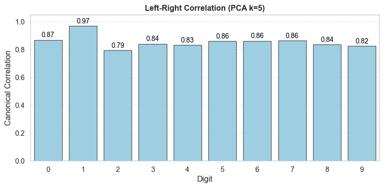

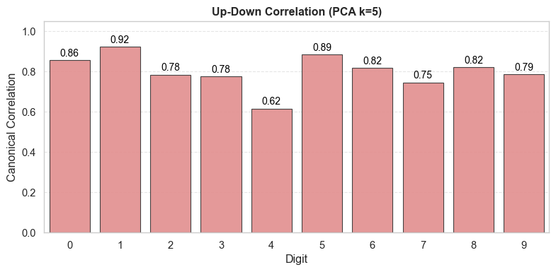

```python
# Figure 4
plot_correlation_summary_bars(X, y, n_components=5)
```

### Figure 5 and 6

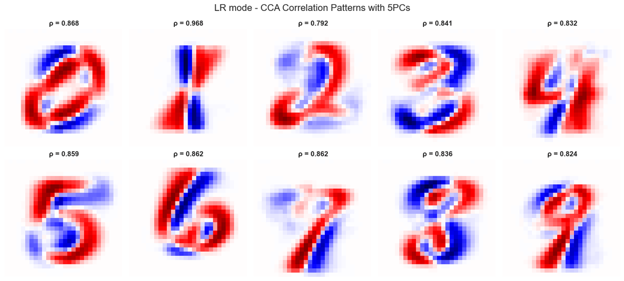

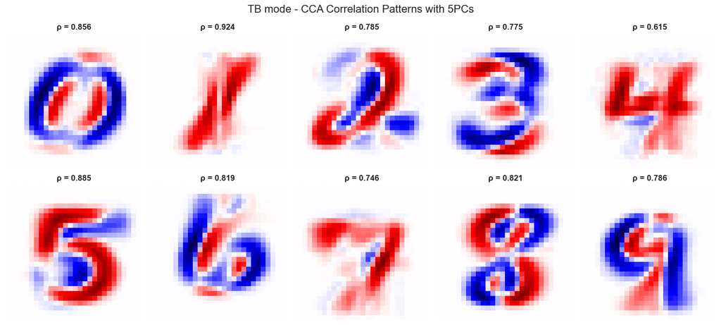

```python
# Figure 5 and Figure 6, Figure 6 is extracted from figure 5.
visualize_cca_geometry(X, y, n_components=5, mode='LR')
visualize_cca_geometry(X, y, n_components=5, mode='TB')
```

### Figure 8

```
Reconstruction of digit 1
Test Set R^2 Score (Left/Right): -0.4346
Test Set R^2 Score (Top/Bottom): 0.2880
Visualizing Test Sample Index: 22
```

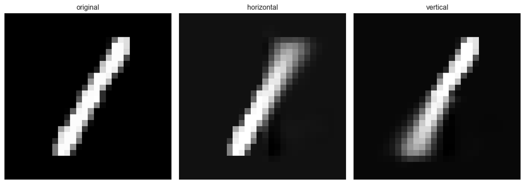

```
Reconstruction of digit 1
Test Set R^2 Score (Left/Right): 0.2200
Test Set R^2 Score (Top/Bottom): 0.2712
Visualizing Test Sample Index: 20
```

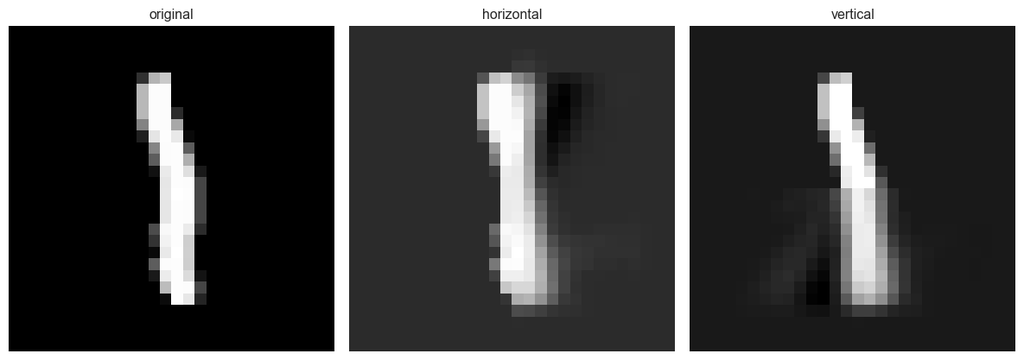

```
Reconstruction of digit 1
Test Set R^2 Score (Left/Right): 0.5171
Test Set R^2 Score (Top/Bottom): 0.3633
Visualizing Test Sample Index: 42
```

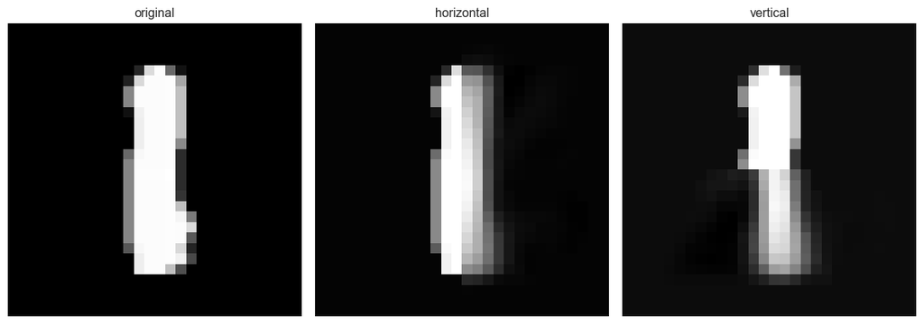

```
Reconstruction of digit 1
Test Set R^2 Score (Left/Right): -0.0158
Test Set R^2 Score (Top/Bottom): 0.2652
Visualizing Test Sample Index: 31
```

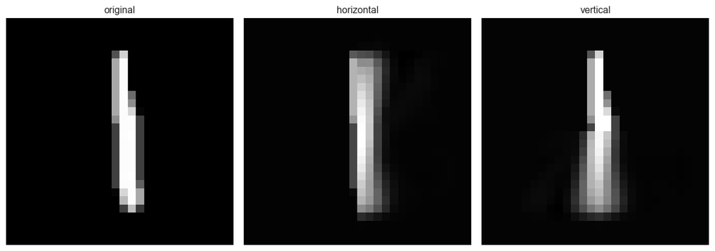

```python
# Figure 8
run_hd_reconstruction_demo(X, y, target_digit=1)
run_hd_reconstruction_demo(X, y, target_digit=1)
run_hd_reconstruction_demo(X, y, target_digit=1)
run_hd_reconstruction_demo(X, y, target_digit=1)
```

### Figure 7

```
 Eigen-Image Matrix Visualization of Digit '1'
```

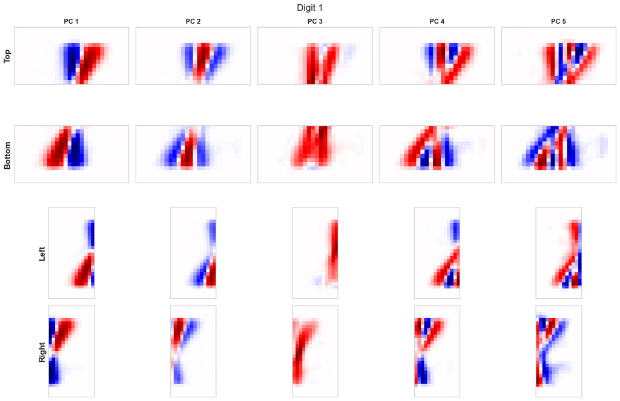

```python
# Figure
visualize_pc_matrix_unified(X, y, target_digit=1, n_components=5)
```

### Figure 9

```
 CCA Weight Barplot - Digit 1, Mode LR
Dominant PC in Left: PC1 (Weight: 0.9026)
```

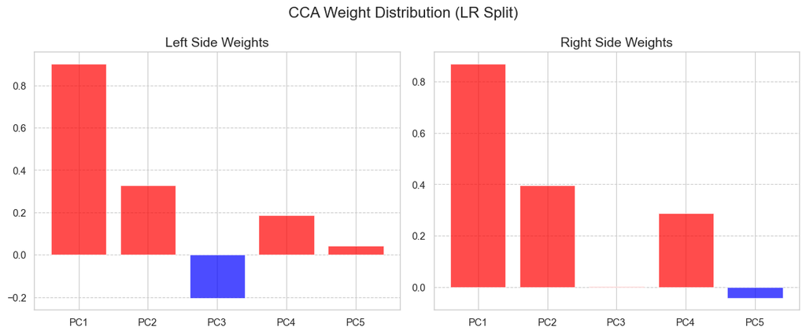

```
 CCA Weight Barplot - Digit 1, Mode TB
Dominant PC in Top: PC3 (Weight: 0.7528)
```

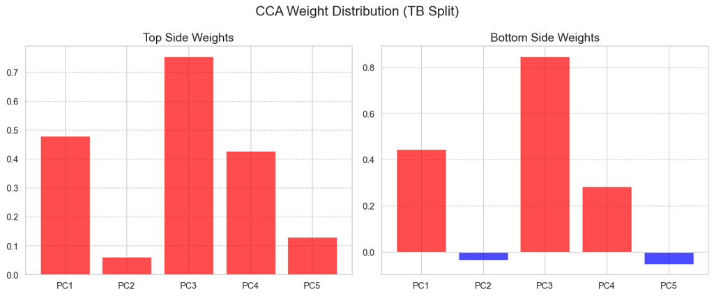

```python
# Figure 9
inspect_cca_weights_unified(X, y, target_digit=1, n_components=5, mode='LR')
inspect_cca_weights_unified(X, y, target_digit=1, n_components=5, mode='TB')
```

### Figure 10

```
 CCA Weight Barplot - Digit 5, Mode LR
Dominant PC in Left: PC1 (Weight: 0.8647)
```

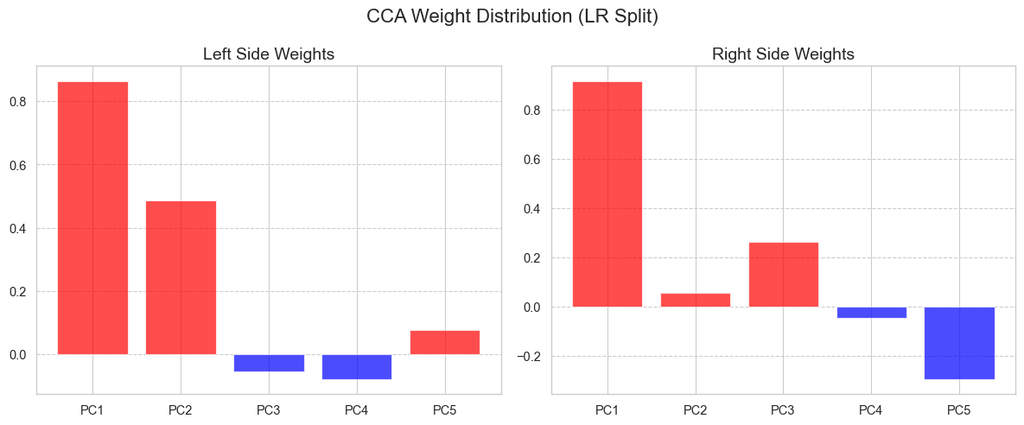

```
 CCA Weight Barplot - Digit 5, Mode TB
Dominant PC in Top: PC1 (Weight: 0.9021)
```

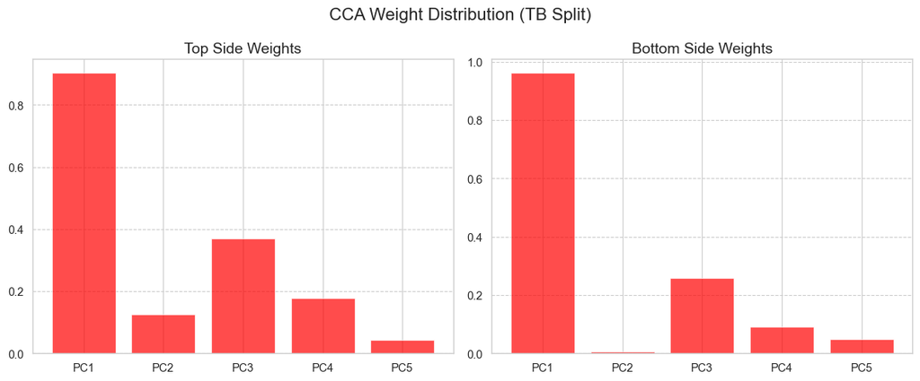

```python
# Figure 10
inspect_cca_weights_unified(X, y, target_digit=5, n_components=5, mode='LR')
inspect_cca_weights_unified(X, y, target_digit=5, n_components=5, mode='TB')
```

### Figure 11

```
Reconstruction of digit 5
Test Set R^2 Score (Left/Right): 0.2807
Test Set R^2 Score (Top/Bottom): 0.3119
Visualizing Test Sample Index: 0
```

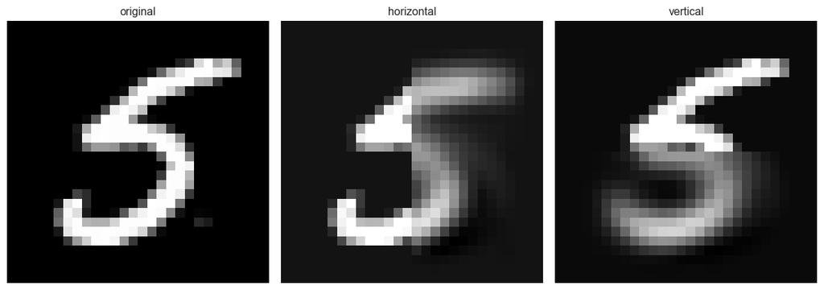

```
Reconstruction of digit 5
Test Set R^2 Score (Left/Right): 0.2042
Test Set R^2 Score (Top/Bottom): 0.1955
Visualizing Test Sample Index: 18
```

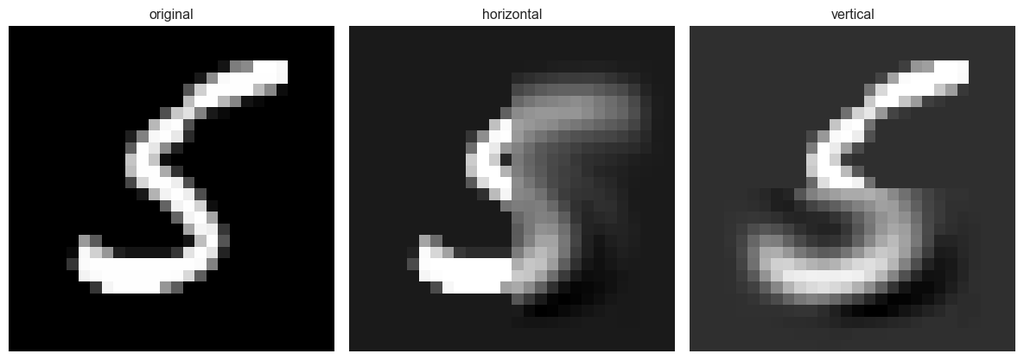

```python
# Figure 11.
run_hd_reconstruction_demo(X, y, target_digit=5)
run_hd_reconstruction_demo(X, y, target_digit=5)
```